# Lab 5: Factors in Visualizations

Author

Kyle Bistrain

```r
library(tidyverse)
library(forcats)
```

```r
surveys <- read_csv(here::here("supporting_artifacts",
                               "learning targets",
                               "surveys.csv"
                               )
                    )
```

## **Revisiting Lab 2**

**1. Reorder the boxplots so the weights go in descending order.**

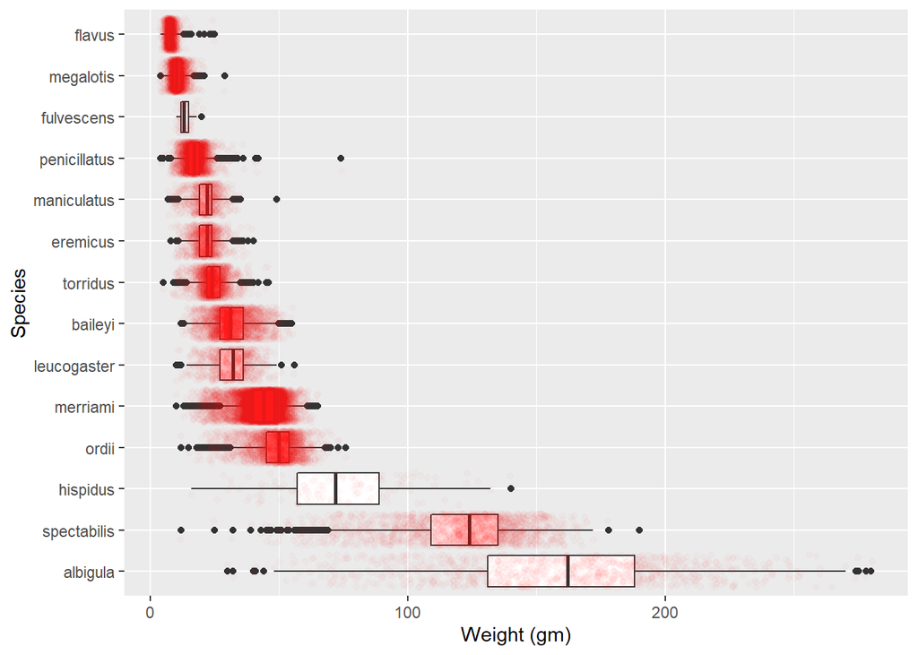

```r
surveys <-
  surveys |>
  mutate(`species` = as_factor(`species`))


ggplot(data = surveys,
  mapping = aes(x = weight,
                y = fct_reorder(species,
                                weight,
                                .desc = TRUE
                                )
                )
       ) +
  geom_boxplot() +
  labs(x = "Weight (gm)",
       y = "Species"
       ) +
  geom_jitter(alpha = .02,
              col = "red"
              )
```

**2. Now that you’ve reordered, look at your y-axis label. That’s long! Let’s take Will Chase’s advice and move the y-axis label to the top of the plot.**

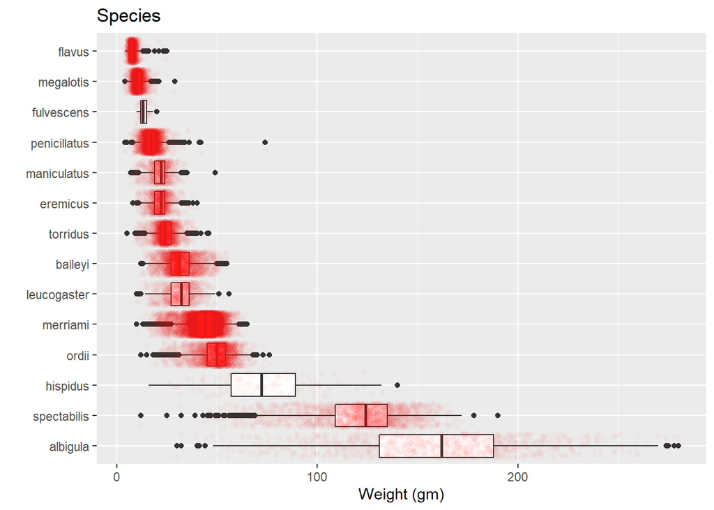

```r
ggplot(data = surveys,
  mapping = aes(x = weight,
                y =  fct_reorder(species,
                                 weight,
                                 .desc = TRUE
                                 )
                )
       ) +
  geom_boxplot() +
  labs(x = "Weight (gm)",
       y = ""
       ) +
  ggtitle("Species") +
  geom_jitter(alpha = .02,
              col = "red"
              )
```

## **Time-Series Plot**

**3. Create a visualization how weights vary for each genus over the duration of the study.**

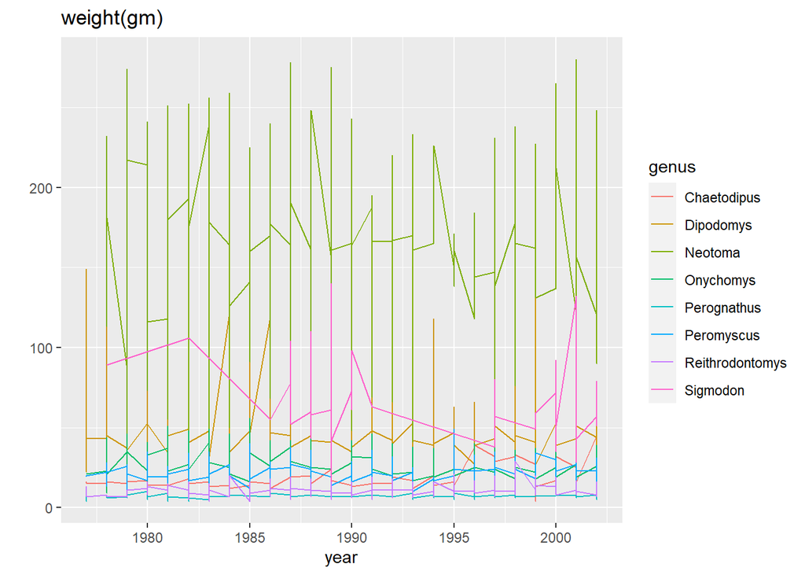

```r
ggplot(data = surveys,
       aes(x = year,
           y = weight,
           color = genus
           )
       ) +
  geom_line(stat = "identity") +
  ggtitle("weight(gm)") +
  labs(y = "")
```

Alright, there are a lot of measurements over time! Let’s use our dplyr skills to summarize each year and plot the summaries.

**4. Calculate and plot the mean weight for each year (for each genus).**

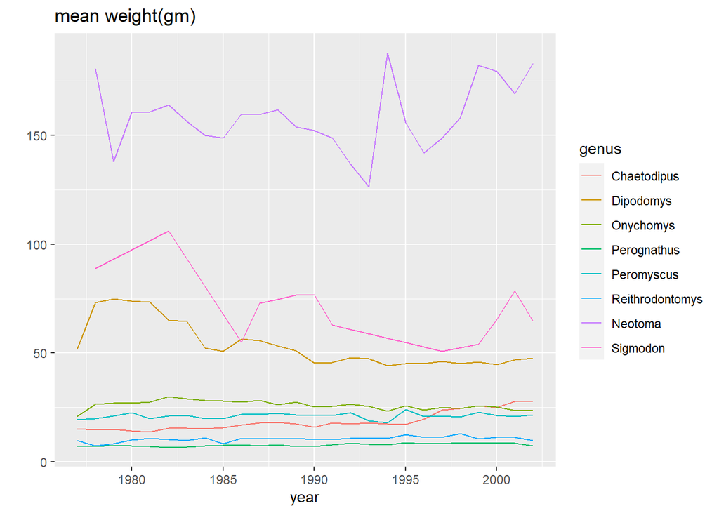

```r
survey_genus <-
  surveys |>
  group_by(year,genus) |>
  mutate(`genus` = as_factor(`genus`)) |>
  summarise(mean = mean(weight),
            .groups = "drop"
            )
ggplot(data = survey_genus,
       aes(x = year,
           y = mean,
           color = genus
           )
       ) +
  geom_line(stat = "identity") +
  labs(x = "year",
       y = ""
       ) +
  ggtitle("mean weight(gm)")
```

**5. Reorder the lines so the weights go in descending order.**

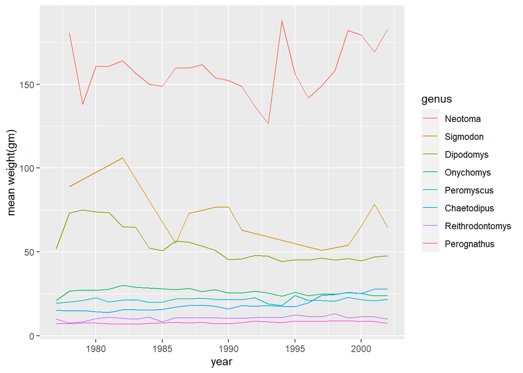

```r
ggplot(data = survey_genus,
       aes(x = year,
           y = mean,
           color = fct_reorder(genus,
                               mean,
                               .desc = TRUE
                               )
           )
       ) +
  labs(color = "genus",
       y = "mean weight(gm)") +
  geom_line(stat = "identity")
```

**6. Now that you’ve reordered the lines, look at your legend’s label. That’s terrible! Let’s give the legend a new title *and* move the information from the y-axis to the plot title.**

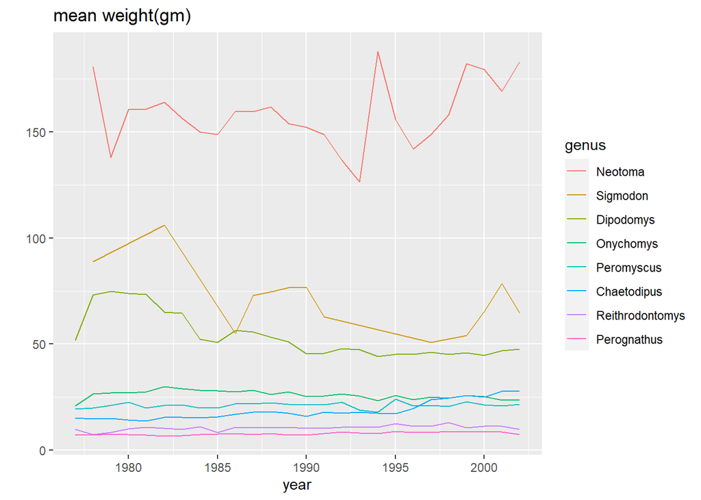

```r
ggplot(data = survey_genus,
       aes(x = year,
           y = mean,
           color = fct_reorder(genus,
                               mean,
                               .desc = TRUE
                               )
           )
       ) +
  labs(color = "genus",
       y = "") +
  ggtitle("mean weight(gm)") +
  geom_line(stat = "identity")
```

## **Caputures over the Week**

**7. Create a visualization of the number of rodents captured each day of the week.**

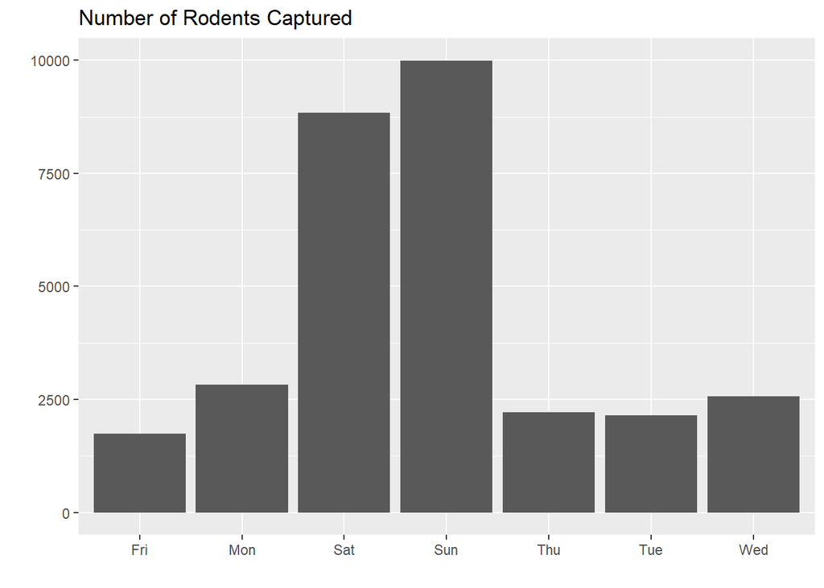

```r
week <-
  surveys |>
  filter(!is.na(day_of_week)) |>
  mutate(as_factor(day_of_week))

ggplot(data = week,
       aes(x = day_of_week)
       ) +
  geom_bar() +
  labs(x = "",
       y = ""
       ) +
  ggtitle("Number of Rodents Captured")
```

As you might have expected, the ordering of the days of the week is not what we would like.

**8. Change the order of the day of the week to go Monday through Sunday.**

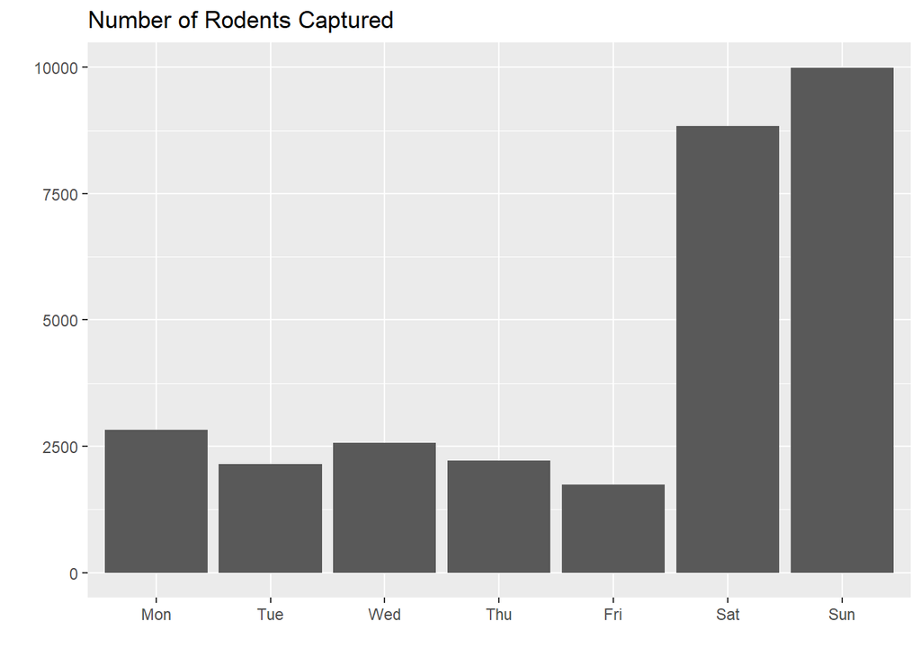

```r
week_order <-
  week |>
  mutate(day_of_week = factor(day_of_week,
                              c("Mon",
                                "Tue",
                                "Wed",
                                "Thu",
                                "Fri",
                                "Sat",
                                "Sun"
                                )
                              )
         )

ggplot(data = week_order,
       aes(x = day_of_week)
       ) +
  geom_bar() +
  labs(x = "",
       y = ""
       ) +
  ggtitle("Number of Rodents Captured")
```

**9. Collapse Monday through Friday into a `"Weekday"` level, and collapse Saturday and Sunday into a `"Weekend"` level. Plot the number of rodents captured between the two groups.**

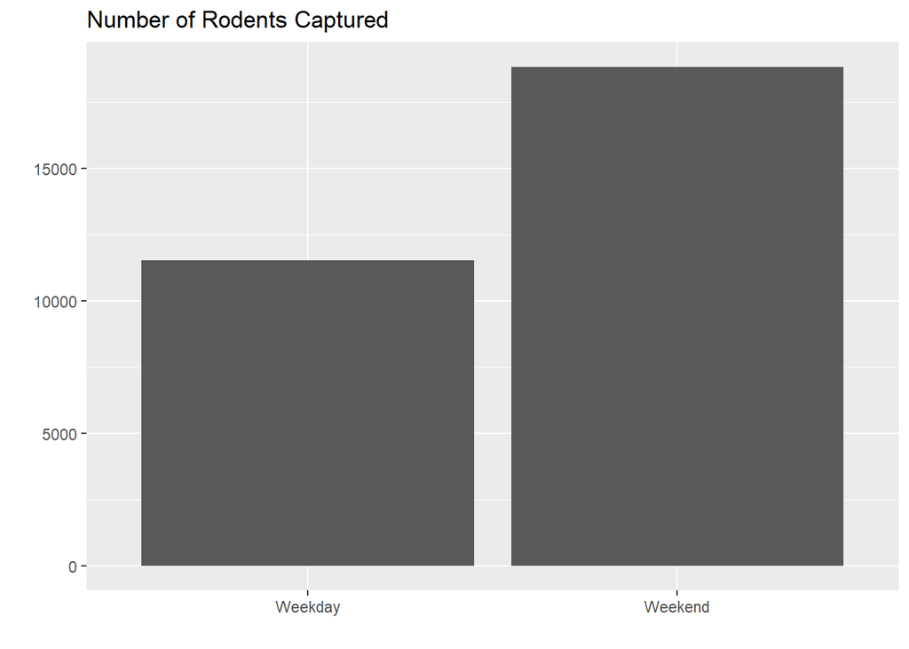

```r
week_bin <-
  week_order |>
  mutate(day_of_week_bin = if_else(day_of_week %in% c("Sat",
                                                      "Sun"
                                                      ),
                                   "Weekend",
                                   "Weekday"
                                   ),
         day_of_week = factor(day_of_week,
                              c("Weekday",
                                "Weekend"
                                )
                              )
         )

ggplot(data = week_bin,
       aes(x = day_of_week_bin)
       ) +
  geom_bar() +
  labs(x = "",
       y = ""
       ) +
  ggtitle("Number of Rodents Captured")
```